# Importing Modules

```python
import pandas as pd
import numpy as np
import io
from urllib.parse import urlparse
from datetime import datetime
import seaborn as sns
from google.colab import files
import re
import warnings
warnings.filterwarnings("ignore")
import matplotlib.pyplot as plt
import scipy.stats
import numpy as np
%matplotlib inline
from prettytable import PrettyTable
from urllib.parse import urlparse
sns.set_theme()
```

# Loading the Dataset

```python
uploaded = files.upload()
```

Upload widget is only available when the cell has been executed in the current browser session. Please rerun this cell to enable.

```
Saving verified_online.csv to verified_online (1).csv
```

```python
data = pd.read_csv(io.BytesIO(uploaded['verified_online.csv']))
```

# Question 1 - Summarize data and share some key insights.

```python
data.head()
```

|  | phish_id | url | phish_detail_url | submission_time | verified | verification_time | online | target |
| --- | --- | --- | --- | --- | --- | --- | --- | --- |
| 0 | 7041471 | https://pagina2.info | http://www.phishtank.com/phish_detail.php?phis... | 2021-03-23T21:04:50+00:00 | yes | 2021-03-23T21:06:57+00:00 | yes | Other |
| 1 | 7041453 | https://obhodrkn.xyz/index.php?_proxurl=https%... | http://www.phishtank.com/phish_detail.php?phis... | 2021-03-23T20:44:15+00:00 | yes | 2021-03-23T20:51:45+00:00 | yes | Other |
| 2 | 7041442 | https://cbt-market.ru//admin/BPD/Notificacione... | http://www.phishtank.com/phish_detail.php?phis... | 2021-03-23T20:32:35+00:00 | yes | 2021-03-23T22:05:48+00:00 | yes | Other |
| 3 | 7041398 | https://www.zonasegurabetabscp.com/app/templat... | http://www.phishtank.com/phish_detail.php?phis... | 2021-03-23T19:19:49+00:00 | yes | 2021-03-23T19:20:57+00:00 | yes | Other |
| 4 | 7041394 | https://www.zonasegurabetabscp.com/ | http://www.phishtank.com/phish_detail.php?phis... | 2021-03-23T19:12:46+00:00 | yes | 2021-03-23T19:14:39+00:00 | yes | Other |

```python
data.info()
```

```
<class 'pandas.core.frame.DataFrame'>
RangeIndex: 10914 entries, 0 to 10913
Data columns (total 8 columns):
 #   Column             Non-Null Count  Dtype
---  ------             --------------  -----
 0   phish_id           10914 non-null  int64
 1   url                10914 non-null  object
 2   phish_detail_url   10914 non-null  object
 3   submission_time    10914 non-null  object
 4   verified           10914 non-null  object
 5   verification_time  10914 non-null  object
 6   online             10914 non-null  object
 7   target             10914 non-null  object
dtypes: int64(1), object(7)
memory usage: 682.2+ KB
```

# Pre-processing the Data

```python
del data['phish_detail_url']
del data['verified']
del data['online']
```

```python
data['time_difference'] = None
data['Submission_Year'] = None
data['Submission_Month'] = None

for i,j in data.iterrows():
  data.loc[i,'submission_time'] = data.loc[i,'submission_time'].split('+')[0]
  data.loc[i,'submission_time'] = datetime.strptime(data.loc[i,'submission_time'], '%Y-%m-%dT%H:%M:%S')
  data.loc[i,'Submission_Year'] = data.loc[i,'submission_time'].year
  data.loc[i,'Submission_Month']= data.loc[i,'submission_time'].strftime("%b")

  data.loc[i,'verification_time'] = data.loc[i,'verification_time'].split('+')[0]
  data.loc[i,'verification_time'] = datetime.strptime(data.loc[i,'verification_time'], '%Y-%m-%dT%H:%M:%S')
  data.loc[i,'time_difference'] = (data.loc[i,'verification_time'] - data.loc[i,'submission_time']).total_seconds()
data['time_difference'] = data['time_difference']/60
```

```python
data.head()
```

|  | phish_id | url | submission_time | verification_time | target | time_difference | Submission_Year | Submission_Month |
| --- | --- | --- | --- | --- | --- | --- | --- | --- |
| 0 | 7041471 | https://pagina2.info | 2021-03-23 21:04:50 | 2021-03-23 21:06:57 | Other | 2.11667 | 2021 | Mar |
| 1 | 7041453 | https://obhodrkn.xyz/index.php?_proxurl=https%... | 2021-03-23 20:44:15 | 2021-03-23 20:51:45 | Other | 7.5 | 2021 | Mar |
| 2 | 7041442 | https://cbt-market.ru//admin/BPD/Notificacione... | 2021-03-23 20:32:35 | 2021-03-23 22:05:48 | Other | 93.2167 | 2021 | Mar |
| 3 | 7041398 | https://www.zonasegurabetabscp.com/app/templat... | 2021-03-23 19:19:49 | 2021-03-23 19:20:57 | Other | 1.13333 | 2021 | Mar |
| 4 | 7041394 | https://www.zonasegurabetabscp.com/ | 2021-03-23 19:12:46 | 2021-03-23 19:14:39 | Other | 1.88333 | 2021 | Mar |

# Key Insights

```python
print("Total number of attacks over the years are:", len(data['phish_id']))
```

```
Total number of attacks over the years are: 10914
```

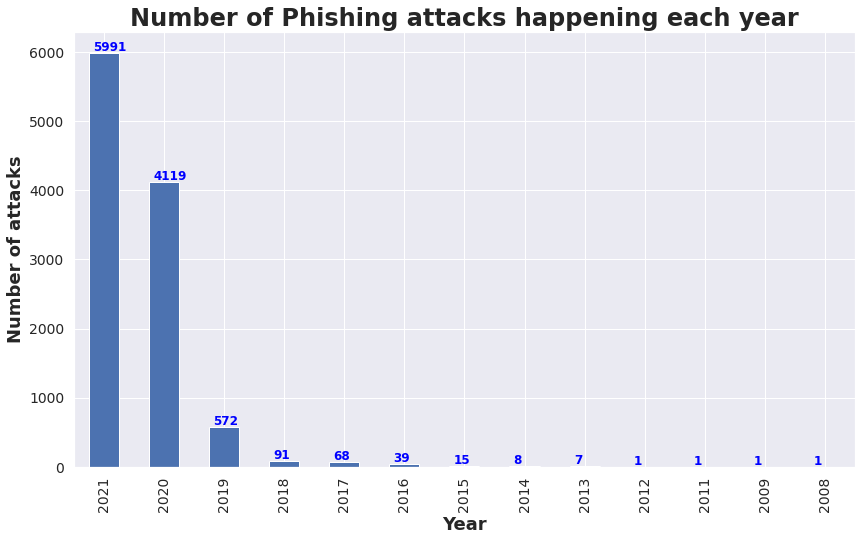

```python
ax = data['Submission_Year'].value_counts().plot(kind='bar', figsize=(14,8))
plt.title("Number of Phishing attacks happening each year",fontname="Times New Roman",fontsize=24, fontweight="bold")

ax.set_xlabel("Year",  fontsize=18, weight='bold')
ax.set_ylabel("Number of attacks",  fontsize=18, weight='bold')
ax.tick_params(axis='x', which='major', labelsize= 14, rotation= 90)
ax.tick_params(axis='y', which='major', labelsize= 14)
#print(data['Submission_Year'].value_counts())
y = data['Submission_Year'].value_counts()
y = y.to_frame()
z = [5991,4119,572,91,68,39,15,8,7,1,1,1,1]
for xx,i in enumerate(z):
  ax.text(xx - 0.18,i + 33,str(i), color='blue', fontweight='bold')
```

There is a expected trend, as the years are passing by there are more and more phishing attacks happening

```python
import statistics
l = [[data['time_difference'].mean(), data['time_difference'].min(), data['time_difference'].max(), statistics.median(data['time_difference']), np.percentile(data['time_difference'], 75), np.percentile(data['time_difference'], 25)]]
table = PrettyTable(["Average time to verify", "Minimum time to verify", "Maximum time to verify", "Median", "75", "25"])
for i in l:
  table.add_row(i)
print("The time statistics are in minutes")
print(table)
```

```
The time statistics are in minutes
+------------------------+------------------------+------------------------+--------------------+---------+-------------------+
| Average time to verify | Minimum time to verify | Maximum time to verify |       Median       |    75   |         25        |
+------------------------+------------------------+------------------------+--------------------+---------+-------------------+
|   8383.154972206958    |  0.26666666666666666   |       1483451.55       | 27.616666666666667 | 1716.45 | 5.754166666666666 |
+------------------------+------------------------+------------------------+--------------------+---------+-------------------+
```

As we can see from the above table, the average time to detect a phishing attack in phistank is around 8300 minutes which is close to 6 days

```python
print("Total number of brands is:", len(list(data['target'].unique())))
```

```
Total number of brands is: 100
```

# Question 2 - What are the top ten phishing target brands through this period. Identify a good visual for this analysis.

Only 1414 of the total rows have target brands, rest all have 'other' listed in the target column. As this is a small portion of the data, I have created the list of the existing brands and searched for these brands in each URL that has other in target column. This way I was able to capture more data.

A new column is added to dataframe i.e., brand which takes the value of target if there is a specific brand for that row. If the target is 'other' then based on the keyword search on the URL it outputs a company. By this way the data was incresead from 1414 to 3200

# Pre-processing the Data

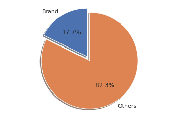

```python
import matplotlib.pyplot as plt
import seaborn as sns
sns.set(style="white", color_codes=False)

labels = 'Brand', 'Others'
sizes = [1414/(6161+1414), 9501/(9501+1414)]
explode = (0, 0.1)  # only "explode" the 2nd slice (i.e. 'Hogs')

fig1, ax1 = plt.subplots()
ax1.pie(sizes, explode=explode, labels=labels, autopct='%1.1f%%',
        shadow=True, startangle=90,)
ax1.axis('equal')  # Equal aspect ratio ensures that pie is drawn as a circle.

plt.show()
```

```python
company_list = data['target'].str.lower()
company_list = company_list.unique()
company_list = company_list[1:]
company_list[company_list == 'amazon.com'] = 'amazon'
company_list[company_list == 'pko polish bank'] = 'pko'
company_list = list(company_list)
company_list.append('royalmail')
company_list.append('llyod')
company_list.remove('ee')
```

```python
data['url'] = data['url'].str.lower()
data['brand'] = None
for i,j in data.iterrows():
  if data.loc[i,'target'].lower()=='other':
    for company in company_list:
      m = re.search(company,data.loc[i,'url'])
      if m and m.group(0)!=None:
        data.loc[i,'brand'] = m.group(0)
        break
  else:
    data.loc[i,'brand'] = data.loc[i,'target']
data['brand'] = data['brand'].str.capitalize()
brand_data = data.dropna()
```

```python
brand_data.head()
```

|  | phish_id | url | submission_time | verification_time | target | time_difference | Submission_Year | Submission_Month | brand |
| --- | --- | --- | --- | --- | --- | --- | --- | --- | --- |
| 8 | 7041090 | http://bill-repayments.com/vodafone/account/ | 2021-03-23 14:44:49 | 2021-03-23 14:52:43 | Vodafone | 7.9 | 2021 | Mar | Vodafone |
| 10 | 7040828 | https://atdropbox.weebly.com/ | 2021-03-23 12:52:17 | 2021-03-23 12:59:22 | Other | 7.08333 | 2021 | Mar | Dropbox |
| 18 | 7040739 | http://182.16.26.237/ap/signin?openid.pape.max... | 2021-03-23 11:54:00 | 2021-03-23 11:58:39 | Other | 4.65 | 2021 | Mar | Amazon |
| 24 | 7040587 | https://voloq.in/.well-known/direct.capitecban... | 2021-03-23 09:24:01 | 2021-03-23 09:29:23 | Capitec Bank | 5.36667 | 2021 | Mar | Capitec bank |
| 26 | 7040585 | https://voloq.in/.well-known/direct.capitecban... | 2021-03-23 09:23:59 | 2021-03-23 09:29:23 | Capitec Bank | 5.4 | 2021 | Mar | Capitec bank |

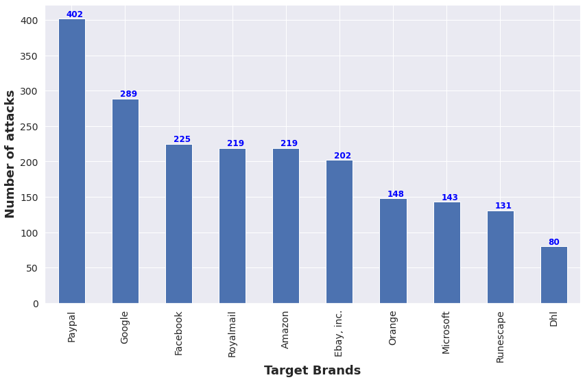

```python
ax = brand_data['brand'].value_counts()[:10].plot(kind='bar', figsize=(14,8))
ax.set_xlabel("Target Brands",  fontsize=18, weight='bold')
ax.set_ylabel("Number of attacks",  fontsize=18, weight='bold')
ax.tick_params(axis='x', which='major', labelsize= 14, rotation= 90)
ax.tick_params(axis='y', which='major', labelsize= 14)
z = [402,289,225,219,219,202,148,143,131,80]
for xx,i in enumerate(z):
  ax.text(xx - 0.1,i + 3,str(i), color='blue', fontweight='bold')
```

```python
import os, sys
from google.colab import drive
drive.mount('/content/drive')
nb_path = '/content/notebooks'
os.symlink('/content/drive/My Drive/Colab Notebooks', nb_path)
sys.path.insert(0,nb_path)
```

```python
!pip install --target=$nb_path squarify
```

```
WARNING: Target directory /content/notebooks/squarify already exists. Specify --upgrade to force replacement.
WARNING: Target directory /content/notebooks/squarify-0.4.3.dist-info already exists. Specify --upgrade to force replacement.
```

```
Paypal        402
Google        289
Facebook      225
Royalmail     219
Amazon        219
Ebay, inc.    202
Orange        148
Microsoft     143
Runescape     131
Dhl            80
Name: brand, dtype: int64
```

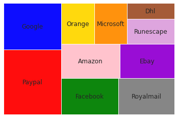

```python
# libraries
import squarify

# Create a data frame with fake data
cc = brand_data['brand'].value_counts()[:10]
color=['red','blue','green','grey','pink','darkviolet','gold','darkorange','plum','sienna']
print(cc)
# plot it
squarify.plot(sizes=[402,289,225,219,219,202,148,143,131,80], label=["Paypal","Google","Facebook","Royalmail","Amazon","Ebay","Orange","Microsoft","Runescape","Dhl"],color=color, alpha=.95)
plt.axis('off')
plt.show()
```

# Question 3 - How have phishing attacks trended over the year?

## By Brands

I have taken top 5 brands from the above graph and observed how they performed each month of the year over the whole time period. There are five line graphs, one for each of those 5 companies.

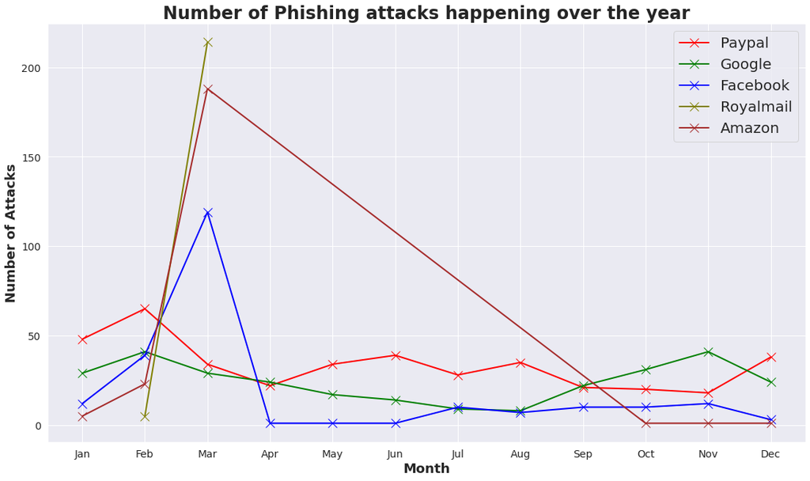

```python
brand_data["Submission_Month_num"] = pd.to_datetime(brand_data.Submission_Month, format='%b', errors='coerce').dt.month
brand_data = brand_data.sort_values(by="Submission_Month")

colors = ['red', 'green', 'blue', 'olive', 'brown']
a = 0
for i in ['Paypal', 'Google', 'Facebook', 'Royalmail', 'Amazon']:
  ref = brand_data[brand_data['brand'] == i].groupby(['Submission_Month',"Submission_Month_num"]).size().reset_index(name='counts')
  ref = ref.sort_values('Submission_Month_num')
  plt.plot(ref['Submission_Month'], ref['counts'], marker = 'x', markerfacecolor=colors[a], markersize=12, color= colors[a], linewidth=2, label = i)
  a += 1

plt.legend()
plt.legend(fontsize=20)
plt.xticks(fontsize=14)
plt.yticks(fontsize=14)
plt.gcf().set_size_inches(18.5, 10.5)
plt.gcf().set_size_inches(18.5, 10.5)
plt.xlabel('Month', fontsize=18, weight='bold')
plt.ylabel('Number of Attacks', fontsize=18, weight='bold')
plt.title("Number of Phishing attacks happening over the year",fontname="Times New Roman",fontsize=24, fontweight="bold")
plt.show()
```

Again, as observed before there is a spike in number of attacks in the month of March. However, companies like Paypal and Google do not follow this trend

## By Protocol

There are two protocols that I want to coduct my analysis on, these are HTTP and HTTPS

```python
protocol_data = data
protocol_data['Protocol'] = None
protocol_data['domain'] = None
protocol_data['domain_type'] = None

for i,j in protocol_data.iterrows():
  parse_object = urlparse(protocol_data.loc[i,'url'])
  protocol_data.loc[i,'Protocol'] = parse_object.scheme
  protocol_data.loc[i,'domain'] = parse_object.netloc
  protocol_data.loc[i,'domain_type'] = protocol_data.loc[i,'domain'].split(".")[-1]
```

```python
protocol_data.head()
```

|  | phish_id | url | submission_time | verification_time | target | time_difference | Submission_Year | Submission_Month | brand | Protocol | domain | domain_type |
| --- | --- | --- | --- | --- | --- | --- | --- | --- | --- | --- | --- | --- |
| 0 | 7041471 | https://pagina2.info | 2021-03-23 21:04:50 | 2021-03-23 21:06:57 | Other | 2.11667 | 2021 | Mar | None | https | pagina2.info | info |
| 1 | 7041453 | https://obhodrkn.xyz/index.php?_proxurl=https%... | 2021-03-23 20:44:15 | 2021-03-23 20:51:45 | Other | 7.5 | 2021 | Mar | None | https | obhodrkn.xyz | xyz |
| 2 | 7041442 | https://cbt-market.ru//admin/bpd/notificacione... | 2021-03-23 20:32:35 | 2021-03-23 22:05:48 | Other | 93.2167 | 2021 | Mar | None | https | cbt-market.ru | ru |
| 3 | 7041398 | https://www.zonasegurabetabscp.com/app/templat... | 2021-03-23 19:19:49 | 2021-03-23 19:20:57 | Other | 1.13333 | 2021 | Mar | None | https | www.zonasegurabetabscp.com | com |
| 4 | 7041394 | https://www.zonasegurabetabscp.com/ | 2021-03-23 19:12:46 | 2021-03-23 19:14:39 | Other | 1.88333 | 2021 | Mar | None | https | www.zonasegurabetabscp.com | com |

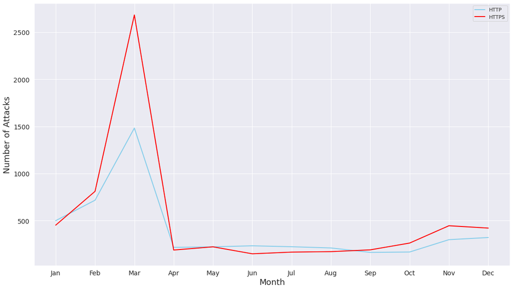

```python
protocol_data["Submission_Month_num"] = pd.to_datetime(protocol_data.Submission_Month, format='%b', errors='coerce').dt.month
protocol_data = protocol_data.sort_values(by="Submission_Month")

http_data = protocol_data[protocol_data['Protocol'] == 'http'].groupby(['Submission_Month',"Submission_Month_num"]).size().reset_index(name='counts')
http_data = http_data.sort_values('Submission_Month_num')

https_data = protocol_data[protocol_data['Protocol'] == 'https'].groupby(['Submission_Month',"Submission_Month_num"]).size().reset_index(name='counts')
https_data = https_data.sort_values('Submission_Month_num')

plt.plot(http_data['Submission_Month'], http_data['counts'], markerfacecolor='blue', markersize=12, color='skyblue', linewidth=2, label = 'HTTP')
plt.plot(https_data['Submission_Month'], https_data['counts'], markerfacecolor='red', markersize=12, color='red', linewidth=2, label = 'HTTPS')

plt.legend()
plt.xticks(fontsize=14)
plt.yticks(fontsize=14)
plt.gcf().set_size_inches(18.5, 10.5)
plt.gcf().set_size_inches(18.5, 10.5)
plt.xlabel('Month', fontsize=18)
plt.ylabel('Number of Attacks', fontsize=18)
plt.show()
```

As we can see from this graph, for both type of protocols, March has more number of Phishing attcks. The subsequent months from March have less attacks because they do not have 2021 data.

## By Method

Here I consider three major methods of targeting users, one by using login credentials, second by asking users to download a form and the last one by using a google form. I have used keyword searches such as 'login', 'docs.google' and 'download' in the URL to segregate them.

- login - Stealing credentials
- docs.google - Duping users by showing them a google form instead of actal page
- download - Asking users to download something

```python
method_data = data
del method_data['brand']
method_data['method'] = None
for i,j in method_data.iterrows():
  if 'docs.google' in method_data.loc[i,'url'] :
    method_data.loc[i,'method'] = 'docs.google'
  if 'download' in method_data.loc[i,'url']:
    method_data.loc[i,'method'] = 'download'
  if 'login' in method_data.loc[i,'url']:
    method_data.loc[i,'method'] = 'login'
method_data = method_data.dropna()
```

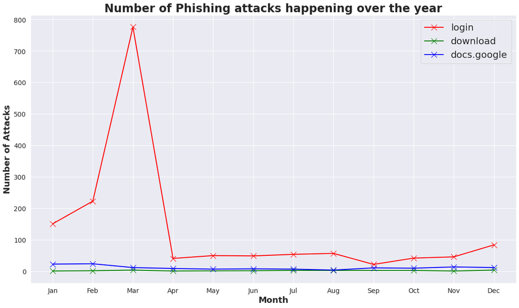

```python
method_data["Submission_Month_num"] = pd.to_datetime(method_data.Submission_Month, format='%b', errors='coerce').dt.month
method_data = method_data.sort_values(by="Submission_Month")

colors = ['red', 'green', 'blue']
a = 0
for i in ['login', 'download', 'docs.google']:
  ref = method_data[method_data['method'] == i].groupby(['Submission_Month',"Submission_Month_num"]).size().reset_index(name='counts')
  ref = ref.sort_values('Submission_Month_num')
  plt.plot(ref['Submission_Month'], ref['counts'], marker = 'x', markerfacecolor=colors[a], markersize=12, color= colors[a], linewidth=2, label = i)
  a += 1

plt.legend(fontsize=20)
plt.xticks(fontsize=14)
plt.yticks(fontsize=14)
plt.gcf().set_size_inches(18.5, 10.5)
plt.gcf().set_size_inches(18.5, 10.5)
plt.xlabel('Month', fontsize=18, weight='bold')
plt.ylabel('Number of Attacks', fontsize=18, weight='bold')
plt.title("Number of Phishing attacks happening over the year",fontname="Times New Roman",fontsize=24, fontweight="bold")
plt.show()
```

# Question - 4 What brand has been the top target and how has that changed?

### Top target has been Paypal as per graph in Question 2

```python
paypal_data = brand_data[brand_data['brand']=='Paypal']
```

```python
vv = paypal_data['Submission_Year'].value_counts()
vv
```

```
2020    167
2021    127
2019     95
2018      6
2017      3
2016      3
2013      1
Name: Submission_Year, dtype: int64
```

[figure not shown]

```python
ax = paypal_data['Submission_Year'].value_counts(sort= False).plot(kind='bar', figsize=(14,8))
ax.set_xlabel("Year",  fontsize=18, weight='bold')
ax.set_ylabel("Number of attacks",  fontsize=18, weight='bold')
ax.tick_params(axis='x', which='major', labelsize= 14, rotation= 0)
ax.tick_params(axis='y', which='major', labelsize= 14)
plt.title("Number of Phishing attacks each year for Paypal",fontname="Times New Roman",fontsize=24, fontweight="bold")
z1 = [1,3,3,6,96,167,127]
for xx,jj in enumerate(z1):
  ax.text(xx-0.1, jj+1.5 ,str(jj), color='blue', fontweight='bold')
```

### My Hypothesis for Paypal being the top most attacked company is the fact that it is a financial service based application. Hackers can easily earn money if they can steal the credentials of users or dupe them to send money to a different account. So, users have to be extremely careful while doing an online transaction from any finacial service

# Question 5 - How the attacks on target brands have changed over the years? Visual?

I have taken top 5 companies and observed the number of attacks over the years for these 5 companies. Each line graph represents one of the five companies.

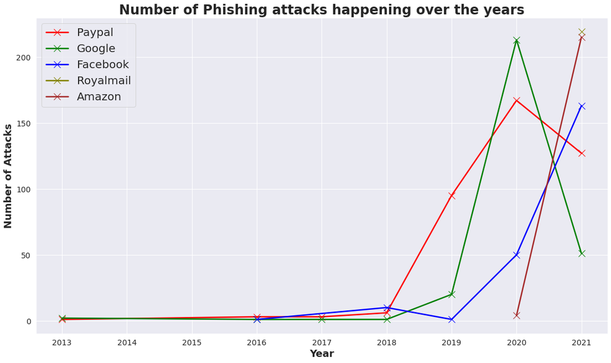

```python
colors = ['red', 'green', 'blue', 'olive', 'brown']
a = 0
for i in ['Paypal', 'Google', 'Facebook', 'Royalmail', 'Amazon']:
  ref = brand_data[brand_data['brand'] == i].groupby('Submission_Year').size().reset_index(name='counts')
  ref = ref.sort_values('Submission_Year')
  plt.plot(ref['Submission_Year'], ref['counts'], marker = 'x', markerfacecolor= colors[a], markersize=12, color= colors[a], linewidth=2.5, label = i)
  a += 1

plt.legend()
plt.legend(fontsize=20)
plt.xticks(fontsize=14)
plt.yticks(fontsize=14)
plt.gcf().set_size_inches(18.5, 10.5)
plt.gcf().set_size_inches(18.5, 10.5)
plt.xlabel('Year', fontsize=18, weight='bold')
plt.ylabel('Number of Attacks', fontsize=18, weight='bold')
plt.title("Number of Phishing attacks happening over the years",fontname="Times New Roman",fontsize=24, fontweight="bold")
plt.show()
```

# Question 6 - Any interesting insights you can draw from the url column?

```python
rr = protocol_data['domain_type'].value_counts()[:10]
rr
```

```
com    6228
ru      389
net     343
org     235
top     200
br      164
fr      130
uk      122
lu      117
ly      105
Name: domain_type, dtype: int64
```

[figure not shown]

```python
ax = protocol_data['domain_type'].value_counts()[:10].plot(kind='bar', figsize=(14,8))
ax.set_xlabel("Domains",  fontsize=18, weight='bold')
ax.set_ylabel("Number of attacks",  fontsize=18, weight='bold')
ax.tick_params(axis='x', which='major', labelsize= 20, rotation= 0)
ax.tick_params(axis='y', which='major', labelsize= 14)
plt.title("Top 10 target phishing brands",fontname="Times New Roman",fontsize=24, fontweight="bold")
z1 = [6228,389,343,235,200,164,130,122,117,105]
for xx,jj in enumerate(z1):
  ax.text(xx-0.2, jj+20 ,str(jj), color='blue', fontweight='bold')
```

I was expecting some of the free domains such as .tk, .ml, .ga, .cf, .gq to show up as the hacker can create as many of these at will since they are free. But it is surprising to see .com to dominate the domains as it is a paid domain.

# Question 7 - Any interesting trends you see in the use of phishing protocol?

```
https    6161
http     4753
Name: Protocol, dtype: int64
```

[figure not shown]

```python
ax = protocol_data['Protocol'].value_counts().plot(kind='bar', figsize=(14,8), title="Top 10 target phishing brands")
ax.set_xlabel("Protocols",  fontsize=18)
ax.set_ylabel("Number of attacks",  fontsize=18)
ax.tick_params(axis='x', which='major', labelsize= 20, rotation= 0)
ax.tick_params(axis='y', which='major', labelsize= 14)
vv =protocol_data['Protocol'].value_counts()
vv
```

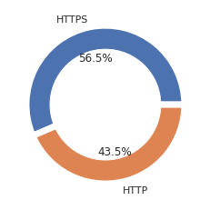

```python
names = 'HTTPS', 'HTTP'
size = [6161/(6161+4753), 4753/(6161+4753)]

# Create a circle at the center of the plot
my_circle = plt.Circle( (0,0), 0.7, color='white')

# Custom wedges
plt.pie(size, labels=names, wedgeprops = { 'linewidth' : 7, 'edgecolor' : 'white' }, autopct='%1.1f%%')
p = plt.gcf()
p.gca().add_artist(my_circle)
plt.show()
```

Interesting fact from here is that there are more phishing attacks happenings even if the protocol is secure (HTTPS)

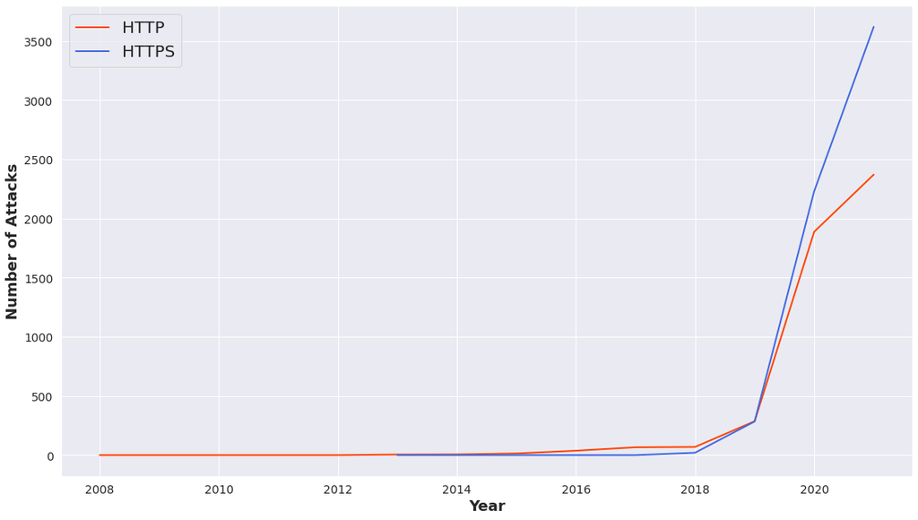

```python
http_data = protocol_data[protocol_data['Protocol'] == 'http'].groupby('Submission_Year').size().reset_index(name='counts')
http_data = http_data.sort_values('Submission_Year')

https_data = protocol_data[protocol_data['Protocol'] == 'https'].groupby('Submission_Year').size().reset_index(name='counts')
https_data = https_data.sort_values('Submission_Year')

plt.plot(http_data['Submission_Year'], http_data['counts'], markerfacecolor='orangered', markersize=12, color='orangered', linewidth=2, label = 'HTTP')
plt.plot(https_data['Submission_Year'], https_data['counts'], markerfacecolor='royalblue', markersize=12, color='royalblue', linewidth=2, label = 'HTTPS')

plt.legend(fontsize=20)
plt.xticks(fontsize=14)
plt.yticks(fontsize=14)
plt.gcf().set_size_inches(18.5, 10.5)
plt.gcf().set_size_inches(18.5, 10.5)
plt.xlabel('Year', fontsize=18, weight='bold')
plt.ylabel('Number of Attacks', fontsize=18, weight='bold')
plt.show()
```

```python
protocol_data['time_difference'] = pd.to_numeric(protocol_data['time_difference'])
protocol_data.groupby('Protocol')['time_difference'].mean()
```

```
Protocol
http     11482.332376
https     5992.245996
Name: time_difference, dtype: float64
```

### Another interesting fact is that the average time taken to verify a phishing attack in Phishtank is higher for HTTP than HTTPS

# Question 8 - What metrics would you like to design for this data?

1. Mean Time to Detect (MTTD): What is the mean response time for your team to respond to a Phishing attack once they are aware of it? A great measure of the quality of your incident response plan implementation
2. The number of brands that are attacked each year. It gives the range of companies that are affected by these Phishing scams.
3. The number of Phishing attacks on a brand over-time. This metric indicates the effectiveness of the Cyber-security team in that particular brand.